# ベイズモデルによるマーケティング現象のモデル化②

## (1) 線形ガウス状態空間モデル①

### データ

```r
setwd("D:/R_Appendix")
df <- read.csv("sec8_DLM.csv")
head(df)
plot(df$LogPI_A, type = "l", ylab = "LogPI_A", xlab = "day")
```

|  | Date | LogPI_A | LogPriceIndex_A | LogPriceIndex_B | Display_A | Display_B |
| --- | --- | --- | --- | --- | --- | --- |
| 1 | 20000102 | 0.02224561 | 0 | -0.127213 | 0 | 0 |
| 2 | 20000103 | 0.18152188 | 0 | -0.127213 | 0 | 0 |
| 3 | 20000104 | -1.34469081 | 0 | -0.127213 | 0 | 0 |
| 4 | 20000105 | -0.48119082 | 0 | -0.127213 | 0 | 0 |
| 5 | 20000106 | 0.20334092 | 0 | -0.127213 | 0 | 0 |
| 6 | 20000107 | -0.01291622 | 0 | -0.127213 | 0 | 0 |

**醤油のPOSデータ**（8.3.3節，p.157）

- Date： 日付
- LogPI_A： 商品Aの点数PI（来店客1000人当たり販売点数）の対数 ($y_t$)
- LogPriceIndex_A： 商品Aの価格掛率の対数 ($x_{t1}$)
- LogPriceIndex_B： 商品Bの価格掛率の対数 ($x_{t2}$)
- Display_A： 商品Aの山積み陳列実施の有無 ($x_{t3}$)
- Display_B： 商品Bの山積み陳列実施の有無 ($x_{t4}$)

[figure not shown]

### モデル

#### 観測モデル

$\hspace{10pt} y_t = \beta_{0,t} + x_t^1 \beta_{1,t} + x_t^2 \beta_{2,t} + x_t^3 \beta_{3,t} + \varepsilon_t; \hspace{5pt} \varepsilon_t \sim N(0, \sigma^2)$

#### システムモデル

$\hspace{10pt} \beta_{0,t} = \beta_{0,t-1}+\nu_t^0; \hspace{5pt} \nu_t^0 \sim N(0, \tau_0^2)$ （トレンド項）

$\hspace{10pt} \beta_{1,t} = \beta_{1,t-1}+\nu_t^1; \hspace{5pt} \nu_t^1 \sim N(0, \tau_1^2)$ （商品Aの価格掛率）

$\hspace{10pt} \beta_{2,t} = \beta_{2,t-1}+\nu_t^2; \hspace{5pt} \nu_t^2 \sim N(0, \tau_2^2)$ （商品Bの価格掛率）

$\hspace{10pt} \beta_{3,t} = \beta_{3,t-1}+\nu_t^3; \hspace{5pt} \nu_t^3 \sim N(0, \tau_3^2)$ （商品Aの山積み陳列）

（上記モデルは商品Bの山積み陳列を除いたモデル3。詳細は教科書p.157を参照。）

### 分析

#### モデルの記述と推定

```r
library(KFAS)   # 事前に KFAS パッケージのインストールが必要
model1 <- SSModel(LogPI_A ~ SSMtrend(1, Q=NA) +
                    SSMregression(~LogPriceIndex_A+LogPriceIndex_B+Display_A, Q=diag(NA,3)), data = df, H = NA)
fit1 <- fitSSM(model1, inits = rep(0,5), method = "L-BFGS-B")
out1 <- KFS(fit1$model, filtering = "state", smoothing = c("state", "mean"))
```

- `SSModel`：推定モデルを記述する関数。回帰分析等と同じ記述方法だが，説明変数部分にシステムモデルを記述。
  - `SSMtrend`：トレンド項 $(\beta_{0,t})$
  - `SSMregression`：説明変数にかかる時変係数 $(\beta_{1,t}, \beta_{2,t}, \beta_{3,t})$
- `fitSSM`：モデルパラメータの最尤推定
- `KFS`：推定されたパラメータのもとでカルマンフィルタとスムーザーを実行

#### 推定結果の図示

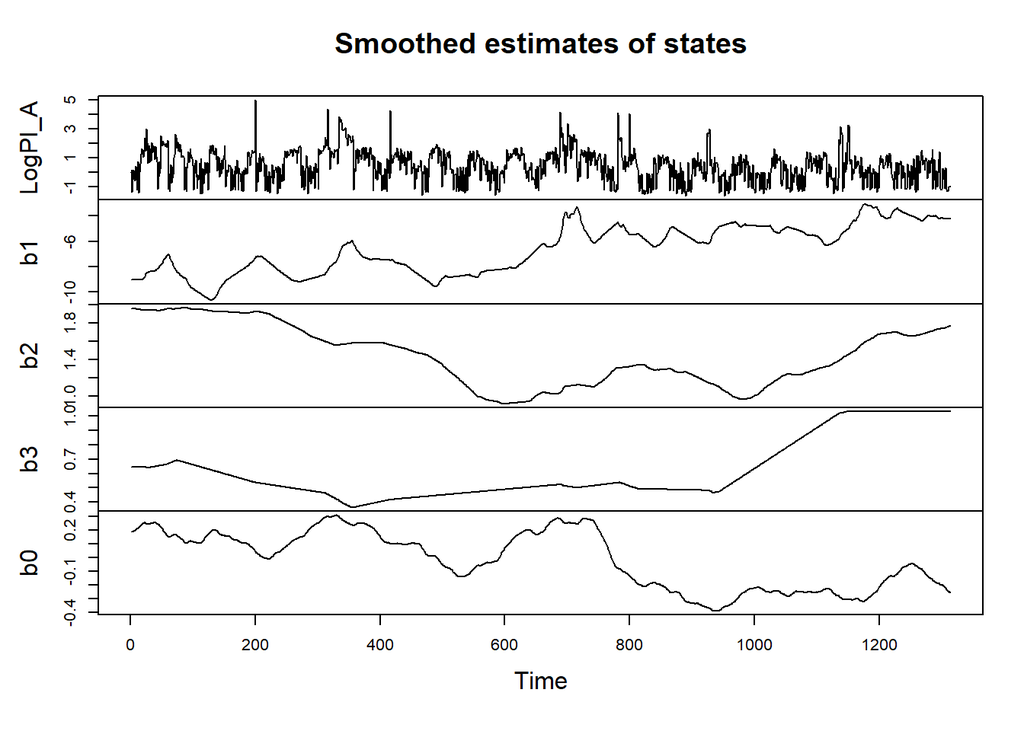

```r
# 推定値プロット
plotdata1 <- cbind(df$LogPI_A, out1$alphahat)
colnames(plotdata1) <- c("LogPI_A", "b1", "b2", "b3", "b0")
plot(plotdata1, nc = 1, main = "Smoothed estimates of states")

# 点数PIとb0（＝商品力）の比較
# plot(plotdata1[,c("LogPI_A", "b0")], plot.type = "single", col = c("black", "red"), ylab = "", main = "LogPI_A and b0")
```

上の段から

- LogPI_A：観測データ（商品Aの点数PIの対数）
- b1：商品Aの価格掛率効果 $(\beta_{1,t})$ の推定値
- b2：商品Bの価格掛率効果 $(\beta_{2,t})$ の推定値
- b3：商品Aの山積み陳列効果 $(\beta_{3,t})$ の推定値
- b0：トレンド項 $(\beta_{0,t})$ の推定値

## (1) 線形ガウス状態空間モデル②

### データ

```r
setwd("D:/R_Appendix")
df <- read.csv("data_tea.csv")
head(df)
plot(df$num, type = "l", ylab = "salse", xlab = "day")
```

|  | date | num | day | holiday |
| --- | --- | --- | --- | --- |
| 1 | 20150401 | 229 | 3 | 0 |
| 2 | 20150402 | 249 | 4 | 0 |
| 3 | 20150403 | 267 | 5 | 0 |
| 4 | 20150404 | 109 | 6 | 0 |
| 5 | 20150405 | 79 | 7 | 1 |
| 6 | 20150406 | 263 | 1 | 0 |

**オフィス街コンビニエンスストアの緑茶ペットボトル売上本数**

- date：日付（2015/04/01 ~ 2015/06/30，91日間）
- num：1日の売上本数 $(y_t)$
- day：曜日番号（1＝月曜，2＝火曜，… ，7＝日曜 ）
- holiday：休日フラグ（1＝日曜・祝日，0＝それ以外） $(x_t)$

[figure not shown]

### モデル①：曜日周期効果

#### 観測モデル

$\hspace{10pt} y_t = \alpha_t + s_t + \varepsilon_t; \hspace{5pt} \varepsilon_t \sim N(0, \sigma^2)$

#### システムモデル

$\hspace{10pt} \alpha_t = \alpha_{t-1}+\nu_t; \hspace{5pt} \nu_t \sim N(0, \tau^2_\alpha)$ （トレンド項）

$\hspace{10pt} s_t = -\sum_{j=1}^6 s_{t-j} + \delta_t; \hspace{5pt} \delta_t \sim N(0, \tau^2_s)$ （曜日周期効果）

#### 行列表記

$$y_t = \begin{bmatrix} 1 & 1 & 0 & 0 & 0 & 0 & 0 \end{bmatrix}
\begin{bmatrix} \alpha_t \\ s_t \\ s_{t-1} \\ s_{t-2} \\ s_{t-3} \\ s_{t-4} \\ s_{t-5} \end{bmatrix} + {\varepsilon}_t$$

$$\begin{bmatrix} \alpha_t \\ s_t \\ s_{t-1} \\ s_{t-2} \\ s_{t-3} \\ s_{t-4} \\ s_{t-5} \end{bmatrix} =
\begin{bmatrix}
1 & 0 & 0 & 0 & 0 & 0 & 0 \\
0 & -1 & -1 & -1 & -1 & -1 & -1 \\
0 & 1 & 0 & 0 & 0 & 0 & 0 \\
0 & 0 & 1 & 0 & 0 & 0 & 0 \\
0 & 0 & 0 & 1 & 0 & 0 & 0 \\
0 & 0 & 0 & 0 & 1 & 0 & 0 \\
0 & 0 & 0 & 0 & 0 & 1 & 0 \\
\end{bmatrix}
\begin{bmatrix} \alpha_{t-1} \\ s_{t-1} \\ s_{t-2} \\ s_{t-3} \\ s_{t-4} \\ s_{t-5} \\ s_{t-6} \end{bmatrix}
+ \begin{bmatrix}
1 & 0 \\
0 & 1 \\
0 & 0 \\
0 & 0 \\
0 & 0 \\
0 & 0 \\
0 & 0 \\
\end{bmatrix}
\begin{bmatrix} \nu_t \\ \delta_t \end{bmatrix}$$

### 分析①：曜日周期効果

#### モデルの記述と推定

```r
library(KFAS)

# 推定用と予測力検証用にデータを分割
df1 <- df[-(85:91),]  # モデルパラメータ推定用のデータ（84日間）
df2 <- df[85:91,]   # モデルの予測力検証用のデータ（7日間）

# モデルパラメータの推定
model2 <- SSModel(num ~ SSMtrend(1, Q = NA) + SSMseasonal(7, sea.type = "dummy", Q = NA), data = df1, H = NA)
fit2 <- fitSSM(model2, inits = rep(0,3), method = "L-BFGS-B")
out2 <- KFS(fit2$model, filtering = "state", smoothing = c("state", "mean"))
```

- `SSModel`：推定モデルを記述する関数。
  - `SSMtrend`：トレンド項 $(\alpha_t)$
  - `SSMseasonal`：周期効果項 $(s_t)$ → `SSMseasonal(7, ...)`で1週間の周期を表現

#### 推定結果の図示

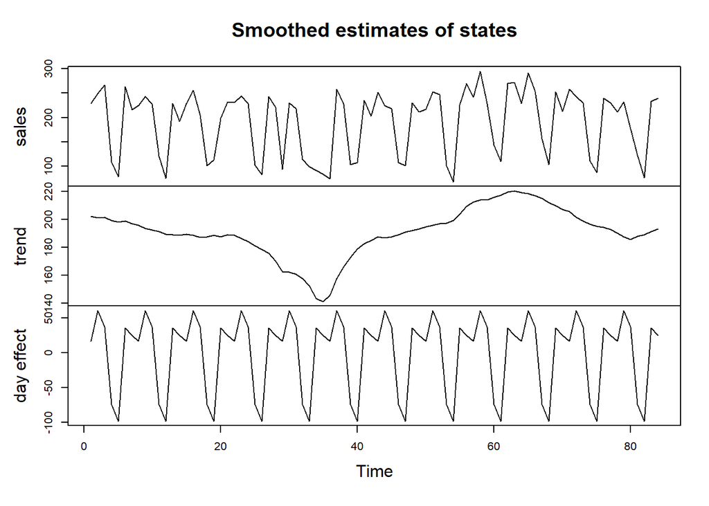

```r
# 推定値プロット
plotdta2 <- cbind(df1$num, out2$alphahat[,1:2])
colnames(plotdta2) <- c("sales", "trend", "day effect")
plot(plotdta2, main = "Smoothed estimates of states")
```

上の段から

- sales：観測データ（1日の売上本数）
- trend：トレンド項 $(\alpha_t)$ の推定値
- day effect：曜日周期効果 $(s_t)$ の推定値

#### 1週先予測

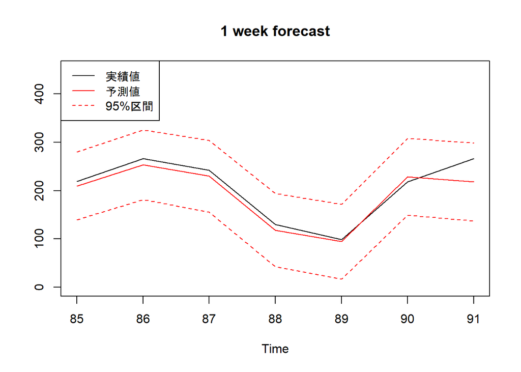

```r
# 売上本数の予測
pred2 <- predict(fit2$model, n.ahead = 7, interval = "prediction", level = 0.95)

# 予測値プロット
cols <- c("black","red","red","red")
ltys <- c("solid","solid","dashed","dashed")
plot(cbind(df2$num, pred2), plot.type = "single", ylim = c(0, 450),
     col = cols, lty = ltys, ylab = "", main = "1 week forecast")
labels <- c("実績値", "予測値", "95%区間")
legend("topleft", legend = labels, col = cols[1:3], lty = ltys[1:3])
```

### モデル②：曜日周期効果＋休日効果

#### 観測モデル

$\hspace{10pt} y_t = \alpha_t + s_t + \beta x_t + \varepsilon_t; \hspace{5pt} \varepsilon_t \sim N(0, \sigma^2_y)$

#### システムモデル

$\hspace{10pt} \alpha_t = \alpha_{t-1}+\nu_t; \hspace{5pt} \nu_t \sim N(0, \sigma^2_\alpha)$ （トレンド項）

$\hspace{10pt} s_t = -\sum_{j=1}^6 s_{t-j} + \delta_t; \hspace{5pt} \delta_t \sim N(0, \sigma^2_s)$ （曜日周期効果）

説明変数$x_t$は休日を表すダミー変数。係数 $\beta$ は時変ではなく，観測期間で共通（時間を通じて変化しない）と仮定する。

### 分析②：曜日周期効果＋休日効果

#### モデルの記述と推定

```r
library(KFAS)
model3 <- SSModel(num ~ SSMtrend(1, Q = NA) + SSMseasonal(7, sea.type = "dummy", Q = NA) +
                    SSMregression(~holiday, Q = 0), data = df1, H = NA)
fit3 <- fitSSM(model3, inits = rep(0,3), method = "L-BFGS-B")
out3 <- KFS(fit3$model, filtering = "state", smoothing = c("state", "mean"))
```

- `SSModel`：推定モデルを記述する関数。
  - `SSMtrend`：トレンド項 $(\alpha_t)$
  - `SSMseasonal`：周期効果項 $(s_t)$
  - `SSMregression`：説明変数にかかる回帰係数 $(\beta)$ → `Q=0`なら時間不変，`Q=NA`なら時変として推定される

#### 推定結果の図示

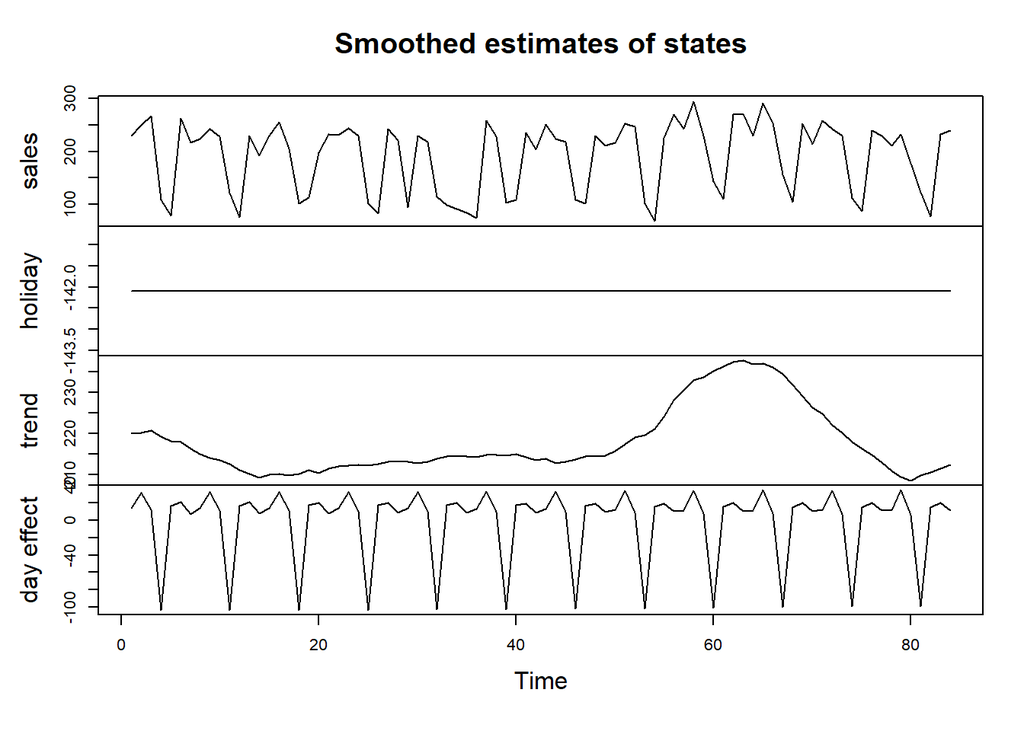

```r
# 推定値プロット
plotdta3 <- cbind(df1$num, out3$alphahat[,1:3])
colnames(plotdta3) <- c("sales", "holiday", "trend", "day effect")
plot(plotdta3, main = "Smoothed estimates of states")
```

上の段から

- sales：観測データ（1日の売上本数）
- holiday：休日効果 $(\beta)$ の推定値
- trend：トレンド項 $(\alpha_t)$ の推定値
- day effect：曜日周期効果 $(s_t)$ の推定値

#### 1週先予測

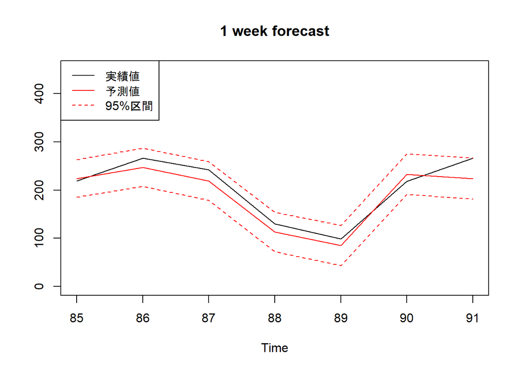

```r
# 予測期間における休日情報を追加
newdata <- SSModel(rep(NA, 7) ~ SSMtrend(1, Q = NA) + SSMseasonal(7, sea.type = "dummy", Q = NA) +
                     SSMregression(~ holiday, Q = 0), data = df2, H = fit3$model$H)
newdata$Q <- fit3$model$Q

# 売上本数の予測
pred3 <- predict(fit3$model, newdata = newdata, interval = "prediction", level = 0.95)

# 予測値プロット
cols <- c("black","red","red","red")
ltys <- c("solid","solid","dashed","dashed")
plot(cbind(df2$num, pred3), plot.type = "single", ylim = c(0, 450),
     col = cols, lty = ltys, ylab = "", main = "1 week forecast")
labels <- c("実績値", "予測値", "95%区間")
legend("topleft", legend = labels, col = cols[1:3], lty = ltys[1:3])
```

モデル①（曜日周期効果）よりもモデル②（曜日周期効果＋休日効果）の方が予測の95％区間が狭い

#### 参考文献

- [岩波データサイエンス刊行委員会編 (2017) 『岩波データサイエンス Vol.6 特集：時系列解析–状態空間モデル・因果解析・ビジネス応用』岩波書店](https://www.iwanami.co.jp/book/b287514.html)
- [野村俊一 (2016) 『カルマンフィルタ』共立出版](http://www.kyoritsu-pub.co.jp/bookdetail/9784320112537)